# Dimentionality_reduction $ Feature_selection

Mildred Kulei

9/10/2021

# **DIMENTIONALITY REDUCTION AND FEATURE SELECTION ANALYSIS**

# 1. Problem Definition

## 1.1 Specifying the Question

### what is the most relevant marketing strategies that will result in the highest no. of sales (total price including tax) in carrefour Kenya.

## 1.2 Metric for success

### Come up with an analysis that will make our client identify the relevant marketing strategies to increase the company’s sales.

## 1.3 Understanding the Context

## 1.4 Experimental Design taken

1. Problem Definition
2. Data Sourcing
3. Check the Data
4. Perform Data Cleaning
5. Perform Exploratory Data Analysis
6. Implement the Solution
7. Challenge the Solution
8. Follow up Questions

## 1.5 Data relevance

### The data collected is relevant as it is was provided by the client from the company’s database.

# 2. Data Sourcing

## Loading the necessary packages

```r
library("data.table")
sales1 <- read.csv("Supermarket_Dataset_1 - Sales Data.csv")
```

# 3. checking the data

```r
##Previewing the first 6 rows of dataset

head(sales1)
```

|  | Invoice.ID | Branch | Customer.type | Gender | Product.line | Unit.price | Quantity | Tax | Date | Time | Payment | cogs | gross.margin.percentage | gross.income | Rating | Total |
| --- | --- | --- | --- | --- | --- | --- | --- | --- | --- | --- | --- | --- | --- | --- | --- | --- |
| 1 | 750-67-8428 | A | Member | Female | Health and beauty | 74.69 | 7 | 26.1415 | 1/5/2019 | 13:08 | Ewallet | 522.83 | 4.761905 | 26.1415 | 9.1 | 548.9715 |
| 2 | 226-31-3081 | C | Normal | Female | Electronic accessories | 15.28 | 5 | 3.8200 | 3/8/2019 | 10:29 | Cash | 76.40 | 4.761905 | 3.8200 | 9.6 | 80.2200 |
| 3 | 631-41-3108 | A | Normal | Male | Home and lifestyle | 46.33 | 7 | 16.2155 | 3/3/2019 | 13:23 | Credit card | 324.31 | 4.761905 | 16.2155 | 7.4 | 340.5255 |
| 4 | 123-19-1176 | A | Member | Male | Health and beauty | 58.22 | 8 | 23.2880 | 1/27/2019 | 20:33 | Ewallet | 465.76 | 4.761905 | 23.2880 | 8.4 | 489.0480 |
| 5 | 373-73-7910 | A | Normal | Male | Sports and travel | 86.31 | 7 | 30.2085 | 2/8/2019 | 10:37 | Ewallet | 604.17 | 4.761905 | 30.2085 | 5.3 | 634.3785 |
| 6 | 699-14-3026 | C | Normal | Male | Electronic accessories | 85.39 | 7 | 29.8865 | 3/25/2019 | 18:30 | Ewallet | 597.73 | 4.761905 | 29.8865 | 4.1 | 627.6165 |

```r
##Previewing the last 6 rows of dataset

tail(sales1)
```

|  | Invoice.ID | Branch | Customer.type | Gender | Product.line | Unit.price | Quantity | Tax | Date | Time | Payment | cogs | gross.margin.percentage | gross.income | Rating | Total |
| --- | --- | --- | --- | --- | --- | --- | --- | --- | --- | --- | --- | --- | --- | --- | --- | --- |
| 995 | 652-49-6720 | C | Member | Female | Electronic accessories | 60.95 | 1 | 3.0475 | 2/18/2019 | 11:40 | Ewallet | 60.95 | 4.761905 | 3.0475 | 5.9 | 63.9975 |
| 996 | 233-67-5758 | C | Normal | Male | Health and beauty | 40.35 | 1 | 2.0175 | 1/29/2019 | 13:46 | Ewallet | 40.35 | 4.761905 | 2.0175 | 6.2 | 42.3675 |
| 997 | 303-96-2227 | B | Normal | Female | Home and lifestyle | 97.38 | 10 | 48.6900 | 3/2/2019 | 17:16 | Ewallet | 973.80 | 4.761905 | 48.6900 | 4.4 | 1022.4900 |
| 998 | 727-02-1313 | A | Member | Male | Food and beverages | 31.84 | 1 | 1.5920 | 2/9/2019 | 13:22 | Cash | 31.84 | 4.761905 | 1.5920 | 7.7 | 33.4320 |
| 999 | 347-56-2442 | A | Normal | Male | Home and lifestyle | 65.82 | 1 | 3.2910 | 2/22/2019 | 15:33 | Cash | 65.82 | 4.761905 | 3.2910 | 4.1 | 69.1110 |
| 1000 | 849-09-3807 | A | Member | Female | Fashion accessories | 88.34 | 7 | 30.9190 | 2/18/2019 | 13:28 | Cash | 618.38 | 4.761905 | 30.9190 | 6.6 | 649.2990 |

```r
##Basic structure of the data
str(sales1)
```

```
## 'data.frame':    1000 obs. of  16 variables:
##  $ Invoice.ID             : chr  "750-67-8428" "226-31-3081" "631-41-3108" "123-19-1176" ...
##  $ Branch                 : chr  "A" "C" "A" "A" ...
##  $ Customer.type          : chr  "Member" "Normal" "Normal" "Member" ...
##  $ Gender                 : chr  "Female" "Female" "Male" "Male" ...
##  $ Product.line           : chr  "Health and beauty" "Electronic accessories" "Home and lifestyle" "Health and beauty" ...
##  $ Unit.price             : num  74.7 15.3 46.3 58.2 86.3 ...
##  $ Quantity               : int  7 5 7 8 7 7 6 10 2 3 ...
##  $ Tax                    : num  26.14 3.82 16.22 23.29 30.21 ...
##  $ Date                   : chr  "1/5/2019" "3/8/2019" "3/3/2019" "1/27/2019" ...
##  $ Time                   : chr  "13:08" "10:29" "13:23" "20:33" ...
##  $ Payment                : chr  "Ewallet" "Cash" "Credit card" "Ewallet" ...
##  $ cogs                   : num  522.8 76.4 324.3 465.8 604.2 ...
##  $ gross.margin.percentage: num  4.76 4.76 4.76 4.76 4.76 ...
##  $ gross.income           : num  26.14 3.82 16.22 23.29 30.21 ...
##  $ Rating                 : num  9.1 9.6 7.4 8.4 5.3 4.1 5.8 8 7.2 5.9 ...
##  $ Total                  : num  549 80.2 340.5 489 634.4 ...
```

```r
# previewing the column names
colnames(sales1)
```

```
##  [1] "Invoice.ID"              "Branch"
##  [3] "Customer.type"           "Gender"
##  [5] "Product.line"            "Unit.price"
##  [7] "Quantity"                "Tax"
##  [9] "Date"                    "Time"
## [11] "Payment"                 "cogs"
## [13] "gross.margin.percentage" "gross.income"
## [15] "Rating"                  "Total"
```

```r
# previewing the dataset
class(sales1)
```

```
## [1] "data.frame"
```

```r
# previewing the datatypes of the dataset
sapply(sales1, class)
```

```
##              Invoice.ID                  Branch           Customer.type
##             "character"             "character"             "character"
##                  Gender            Product.line              Unit.price
##             "character"             "character"               "numeric"
##                Quantity                     Tax                    Date
##               "integer"               "numeric"             "character"
##                    Time                 Payment                    cogs
##             "character"             "character"               "numeric"
## gross.margin.percentage            gross.income                  Rating
##               "numeric"               "numeric"               "numeric"
##                   Total
##               "numeric"
```

```r
# checking the shape of the data
dim(sales1)
```

```
## [1] 1000   16
```

The dataset has 1000 records of data and 16 columns.

# 4. Perform Data Cleaning

## missing values

```r
# checking for missing values
sum(is.na(sales1))
```

```
## [1] 0
```

no missing values.

## Duplicates

```r
# Identifying duplicates
duplicates <- sales1[duplicated(sales1), ]
head(duplicates)
```

| Invoice.ID | Branch | Customer.type | Gender | Product.line | Unit.price | Quantity | Tax | Date | Time | Payment | cogs | gross.margin.percentage | gross.income | Rating | Total |
| --- | --- | --- | --- | --- | --- | --- | --- | --- | --- | --- | --- | --- | --- | --- | --- |

There are no duplicates

## Outliers

```r
#install.packages("dplyr")    # alternative installation of the %>%

library(dplyr)
```

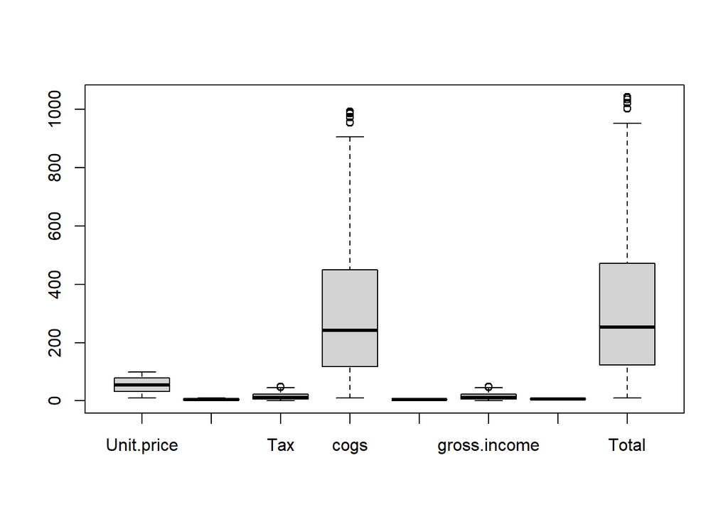

```r
numeric_df <- sales1 %>% select_if(is.numeric)
boxplot(numeric_df)
```

We notice that the column Cogs and Total have a few outliers

## changing column names to make them uniform

```r
colnames(sales1) = tolower(colnames(sales1))
```

```r
#to confirm the change
names (sales1)
```

```
##  [1] "invoice.id"              "branch"
##  [3] "customer.type"           "gender"
##  [5] "product.line"            "unit.price"
##  [7] "quantity"                "tax"
##  [9] "date"                    "time"
## [11] "payment"                 "cogs"
## [13] "gross.margin.percentage" "gross.income"
## [15] "rating"                  "total"
```

## Dropping columns that we do not need

```r
#gross.income and tax are the same so we will drop one,
#we also don't need invoice id in our analysis.

sales1[ ,c('tax','invoice.id')] <- list(NULL)
```

```r
#to confirm they have been deleted
names(sales1)
```

```
##  [1] "branch"                  "customer.type"
##  [3] "gender"                  "product.line"
##  [5] "unit.price"              "quantity"
##  [7] "date"                    "time"
##  [9] "payment"                 "cogs"
## [11] "gross.margin.percentage" "gross.income"
## [13] "rating"                  "total"
```

```r
#separating the date column into 'year','month','day'
library(tidyr)

sales1_date <- separate(sales1, date, c("month", "day", "year"))
head(sales1_date,n=2)
```

|  | branch | customer.type | gender | product.line | unit.price | quantity | month | day | year | time | payment | cogs | gross.margin.percentage | gross.income | rating | total |
| --- | --- | --- | --- | --- | --- | --- | --- | --- | --- | --- | --- | --- | --- | --- | --- | --- |
| 1 | A | Member | Female | Health and beauty | 74.69 | 7 | 1 | 5 | 2019 | 13:08 | Ewallet | 522.83 | 4.761905 | 26.1415 | 9.1 | 548.9715 |
| 2 | C | Normal | Female | Electronic accessories | 15.28 | 5 | 3 | 8 | 2019 | 10:29 | Cash | 76.40 | 4.761905 | 3.8200 | 9.6 | 80.2200 |

We notice that our data is from the year 2019

```r
library(tidyverse)
library(magrittr)
```

```r
#Factors are used to represent categorical data and are important for statistical analysis and for plotting.
#For the categorical data we will change to levels

sales1_cat= c('branch', 'customer.type', 'gender', 'product.line', 'payment', 'year','month','day')

# Changing columns to factors

sales1_date[,sales1_cat] %<>% lapply(function(x) as.factor(as.character(x)))
str(sales1_date)
```

```
## 'data.frame':    1000 obs. of  16 variables:
##  $ branch                 : Factor w/ 3 levels "A","B","C": 1 3 1 1 1 3 1 3 1 2 ...
##  $ customer.type          : Factor w/ 2 levels "Member","Normal": 1 2 2 1 2 2 1 2 1 1 ...
##  $ gender                 : Factor w/ 2 levels "Female","Male": 1 1 2 2 2 2 1 1 1 1 ...
##  $ product.line           : Factor w/ 6 levels "Electronic accessories",..: 4 1 5 4 6 1 1 5 4 3 ...
##  $ unit.price             : num  74.7 15.3 46.3 58.2 86.3 ...
##  $ quantity               : int  7 5 7 8 7 7 6 10 2 3 ...
##  $ month                  : Factor w/ 3 levels "1","2","3": 1 3 3 1 2 3 2 2 1 2 ...
##  $ day                    : Factor w/ 31 levels "1","10","11",..: 27 30 23 20 30 18 18 17 2 13 ...
##  $ year                   : Factor w/ 1 level "2019": 1 1 1 1 1 1 1 1 1 1 ...
##  $ time                   : chr  "13:08" "10:29" "13:23" "20:33" ...
##  $ payment                : Factor w/ 3 levels "Cash","Credit card",..: 3 1 2 3 3 3 3 3 2 2 ...
##  $ cogs                   : num  522.8 76.4 324.3 465.8 604.2 ...
##  $ gross.margin.percentage: num  4.76 4.76 4.76 4.76 4.76 ...
##  $ gross.income           : num  26.14 3.82 16.22 23.29 30.21 ...
##  $ rating                 : num  9.1 9.6 7.4 8.4 5.3 4.1 5.8 8 7.2 5.9 ...
##  $ total                  : num  549 80.2 340.5 489 634.4 ...
```

We observe that: there rae two types of customer; member and normal. There are three branches. there are two types of gender. There are three types of payments. the data is only for 2019. we have 3 months and 31 days. there are 6 types of product line.

```r
#we separate our datatypes columns we divide them into numerical and into categorical
# we had already defined categorical but need numerical

sales1_num <- subset(sales1_date, select = c(unit.price, quantity,cogs,gross.margin.percentage, gross.income, rating ,total))
head(sales1_num,n=3)
```

|  | unit.price | quantity | cogs | gross.margin.percentage | gross.income | rating | total |
| --- | --- | --- | --- | --- | --- | --- | --- |
| 1 | 74.69 | 7 | 522.83 | 4.761905 | 26.1415 | 9.1 | 548.9715 |
| 2 | 15.28 | 5 | 76.40 | 4.761905 | 3.8200 | 9.6 | 80.2200 |
| 3 | 46.33 | 7 | 324.31 | 4.761905 | 16.2155 | 7.4 | 340.5255 |

```r
#we can go ahead and change the above dataframes into tibbles for easier
sales1_numt<-as_tibble(sales1_num)
head(sales1_numt,n=3)
```

| unit.price | quantity | cogs | gross.margin.percentage | gross.income | rating | total |
| --- | --- | --- | --- | --- | --- | --- |
| 74.69 | 7 | 522.83 | 4.761905 | 26.1415 | 9.1 | 548.9715 |
| 15.28 | 5 | 76.40 | 4.761905 | 3.8200 | 9.6 | 80.2200 |
| 46.33 | 7 | 324.31 | 4.761905 | 16.2155 | 7.4 | 340.5255 |

```r
sales1_cat <- subset(sales1_date, select = c(branch, customer.type, gender, product.line, payment, year,month,day))
head(sales1_cat,n=3)
```

|  | branch | customer.type | gender | product.line | payment | year | month | day |
| --- | --- | --- | --- | --- | --- | --- | --- | --- |
| 1 | A | Member | Female | Health and beauty | Ewallet | 2019 | 1 | 5 |
| 2 | C | Normal | Female | Electronic accessories | Cash | 2019 | 3 | 8 |
| 3 | A | Normal | Male | Home and lifestyle | Credit card | 2019 | 3 | 3 |

```r
#category columns as tible
sales1_cat_t<-as_tibble(sales1_cat)
head(sales1_cat_t,n=3)
```

| branch | customer.type | gender | product.line | payment | year | month | day |
| --- | --- | --- | --- | --- | --- | --- | --- |
| A | Member | Female | Health and beauty | Ewallet | 2019 | 1 | 5 |
| C | Normal | Female | Electronic accessories | Cash | 2019 | 3 | 8 |
| A | Normal | Male | Home and lifestyle | Credit card | 2019 | 3 | 3 |

# 5. Exploratory Data Analysis (Univariate, Bivariate & Multivariate)

## 5.1 Univariate Analysis

```r
library(ggplot2)
library(psych)
#Descriptive analysis into measures of central Tendency

describe(sales1_numt)
```

|  | vars | n | mean | sd | median | trimmed | mad | min | max | range | skew | kurtosis | se |
| --- | --- | --- | --- | --- | --- | --- | --- | --- | --- | --- | --- | --- | --- |
| unit.price | 1 | 1000 | 55.672130 | 26.494628 | 55.230000 | 55.617800 | 33.36591 | 10.080000 | 99.960000 | 89.8800 | 0.007056230 | -1.22206222 | 0.83783371 |
| quantity | 2 | 1000 | 5.510000 | 2.923431 | 5.000000 | 5.512500 | 2.96520 | 1.000000 | 10.000000 | 9.0000 | 0.012902251 | -1.21903927 | 0.09244699 |
| cogs | 3 | 1000 | 307.587380 | 234.176510 | 241.760000 | 279.911063 | 222.64945 | 10.170000 | 993.000000 | 982.8300 | 0.889893881 | -0.09329206 | 7.40531145 |
| gross.margin.percentage | 4 | 1000 | 4.761905 | 0.000000 | 4.761905 | 4.761905 | 0.00000 | 4.761905 | 4.761905 | 0.0000 | NaN | NaN | 0.00000000 |
| gross.income | 5 | 1000 | 15.379369 | 11.708825 | 12.088000 | 13.995553 | 11.13247 | 0.508500 | 49.650000 | 49.1415 | 0.889893881 | -0.09329206 | 0.37026557 |
| rating | 6 | 1000 | 6.972700 | 1.718580 | 7.000000 | 6.973125 | 2.22390 | 4.000000 | 10.000000 | 6.0000 | 0.008982638 | -1.15552546 | 0.05434628 |
| total | 7 | 1000 | 322.966749 | 245.885335 | 253.848000 | 293.906616 | 233.78193 | 10.678500 | 1042.650000 | 1031.9715 | 0.889893881 | -0.09329206 | 7.77557702 |

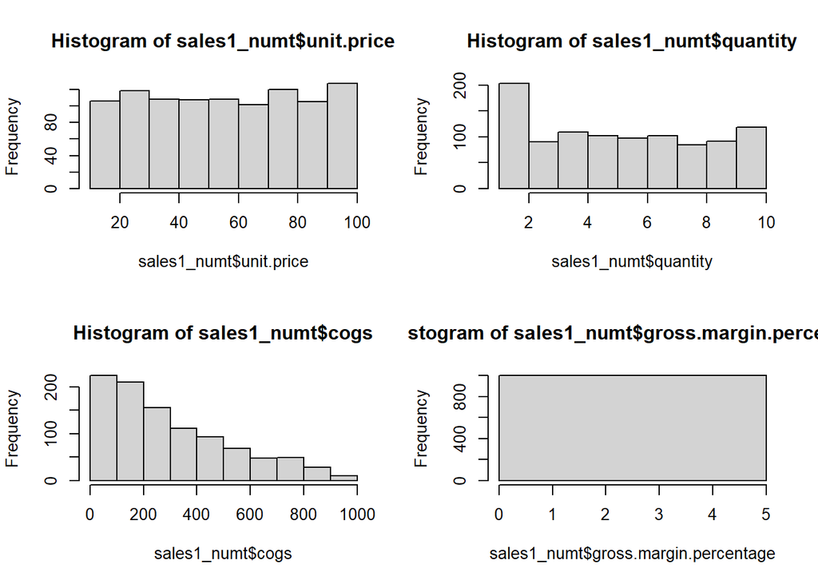

```r
par(mfrow = c(2, 2))
hist(sales1_numt$unit.price)
hist(sales1_numt$quantity)
hist(sales1_numt$cogs)
hist(sales1_numt$gross.margin.percentage)
```

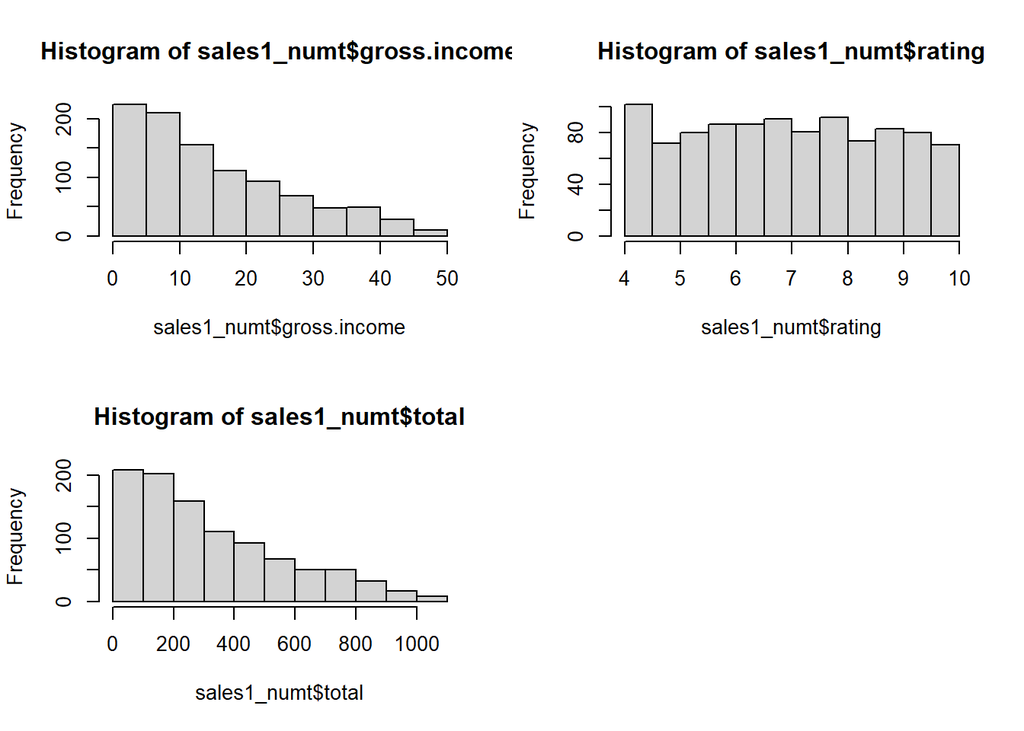

```r
hist(sales1_numt$gross.income)
hist(sales1_numt$rating)
hist(sales1_numt$total)
```

```r
par(mfrow = c(2, 2))
f1 <- sales1_cat$branch
f1y<- table(f1)
head.matrix(f1y)
```

```
## f1
##   A   B   C
## 340 332 328
```

```r
f2 <- sales1_cat$customer.type
f2y<- table(f2)
head.matrix(f2y)
```

```
## f2
## Member Normal
##    501    499
```

```r
f3 <- sales1_cat$gender
f3y<- table(f3)
head.matrix(f3y)
```

```
## f3
## Female   Male
##    501    499
```

```r
f4 <- sales1_cat$product.line
f4y<- table(f4)
head.matrix(f4y)
```

```
## f4
## Electronic accessories    Fashion accessories     Food and beverages
##                    170                    178                    174
##      Health and beauty     Home and lifestyle      Sports and travel
##                    152                    160                    166
```

```r
f5 <- sales1_cat$payment
f5y<- table(f5)
head.matrix(f5y)
```

```
## f5
##        Cash Credit card     Ewallet
##         344         311         345
```

```r
f6 <- sales1_cat$month
f6y<- table(f6)
head.matrix(f6y)
```

```
## f6
##   1   2   3
## 352 303 345
```

```r
f7 <- sales1_cat$day
f7y<- table(f7)
head.matrix(f7y)
```

```
## f7
##  1 10 11 12 13 14
## 28 32 27 31 28 39
```

the higest bought product is fashion accessories, and the lowest is health and beauty. the customer types both ahve almos same number of customers. the first month had highest sales then followed by the third and lastly the secodn month. both genders have almost same numbers.

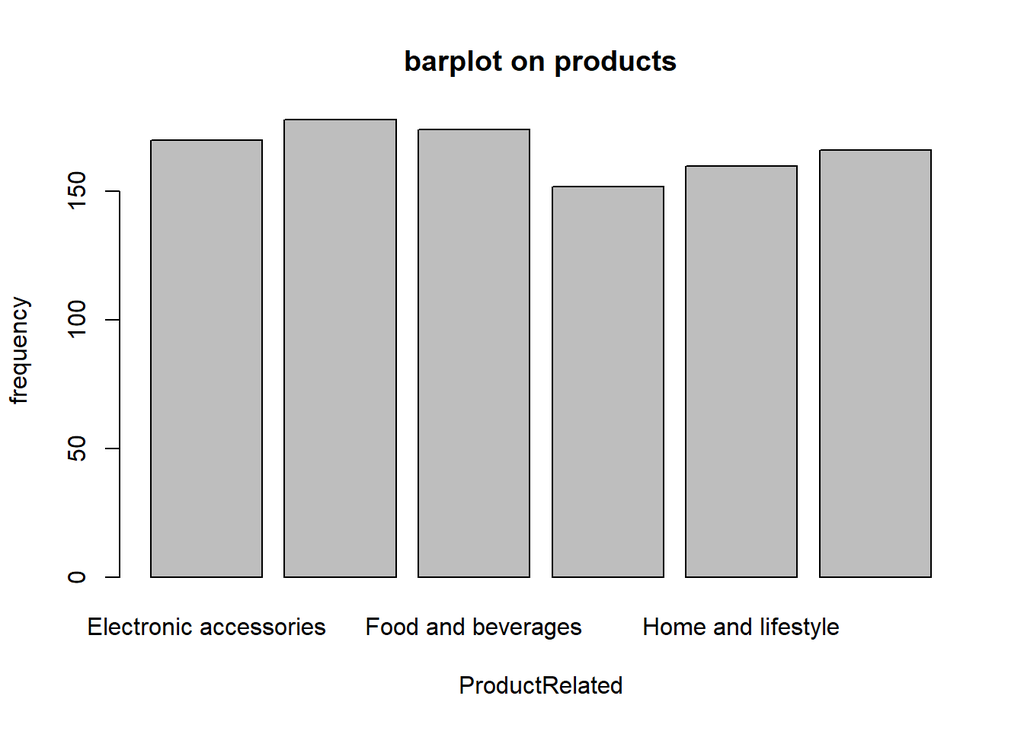

```r
# fetching the columns
products <- sales1_cat$product.line

# fetching the frequency distribution
product_frequency <- table(products)

# plotting the bargraph
barplot(product_frequency,  xlab = 'ProductRelated', ylab = 'frequency',  main = 'barplot on products')
```

Health and beauty had the lowest sales though not much worrying difference.

## 5.2 Bivariate analysis

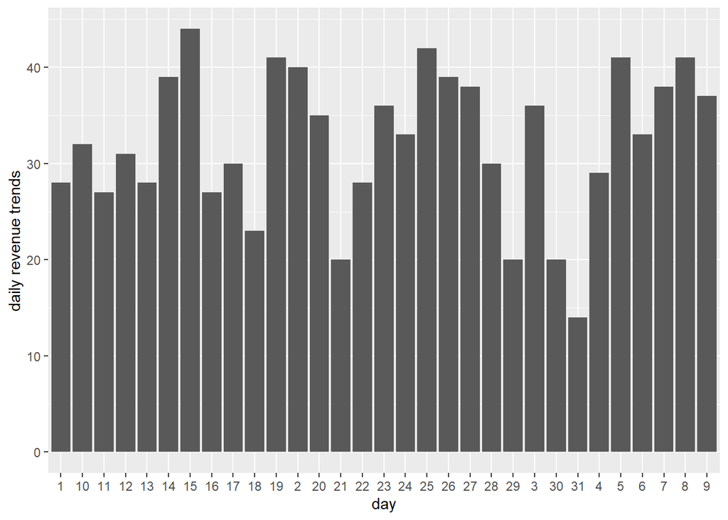

```r
sales1_date %>%
ggplot() +
aes(x = day, gross.income = ..count../nrow(sales1_date), fill = gross.income) +
geom_bar() +
ylab("daily revenue trends")
```

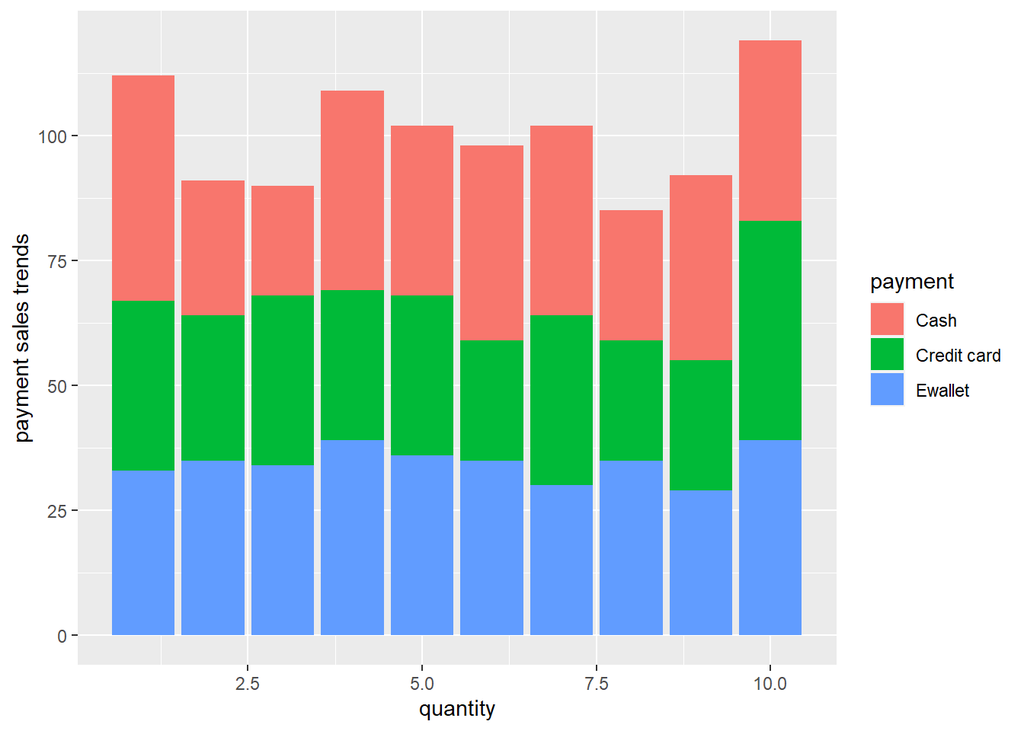

```r
sales1_date %>%
ggplot() +
aes(x = quantity, payment = ..count../nrow(sales1_date), fill = payment) +
geom_bar() +
ylab("payment sales trends")
```

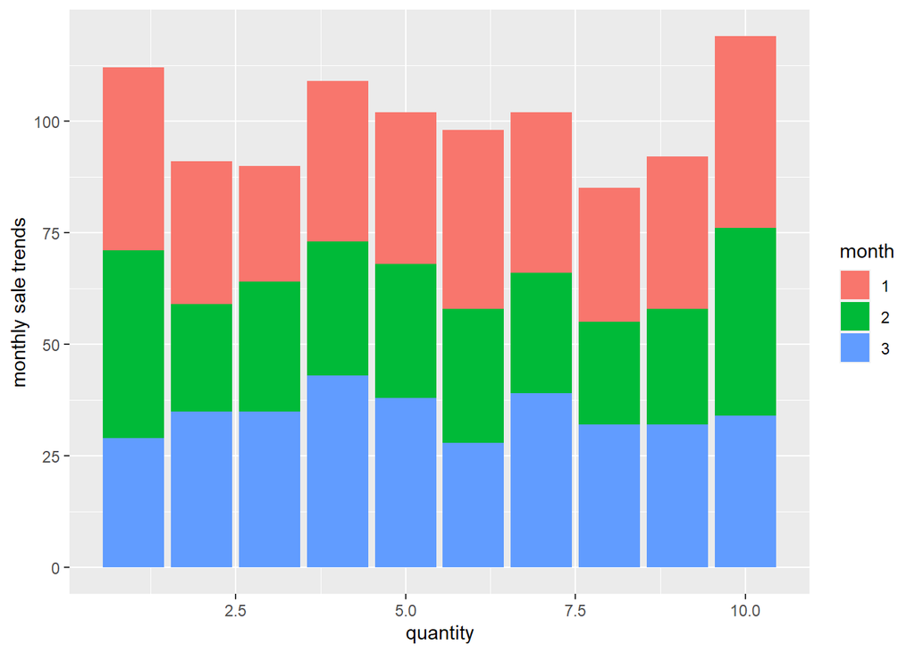

```r
sales1_date %>%
ggplot() +
aes(x = quantity, month = ..count../nrow(sales1_date), fill = month) +
geom_bar() +
ylab("monthly sale trends")
```

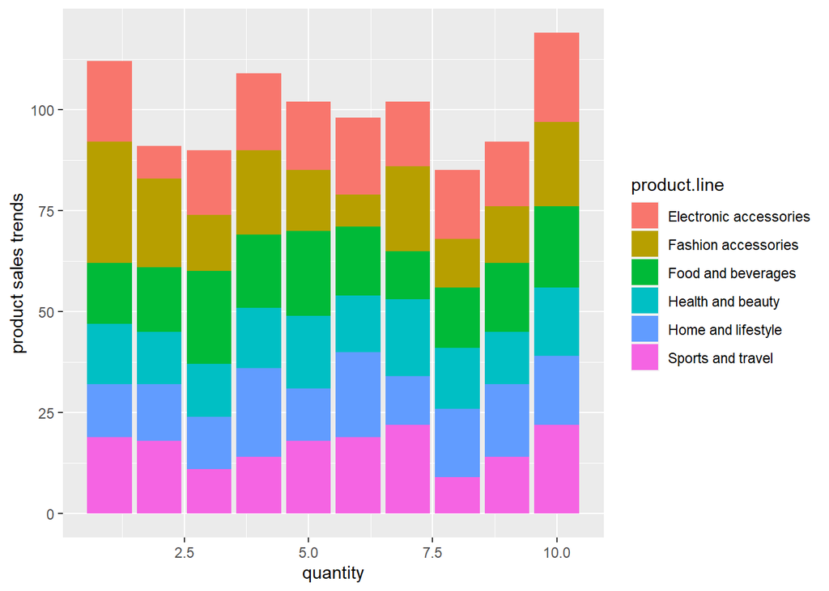

```r
sales1_date %>%
ggplot() +
aes(x = quantity, product.line = ..count../nrow(sales1_date), fill = product.line) +
geom_bar() +
ylab("product sales trends")
```

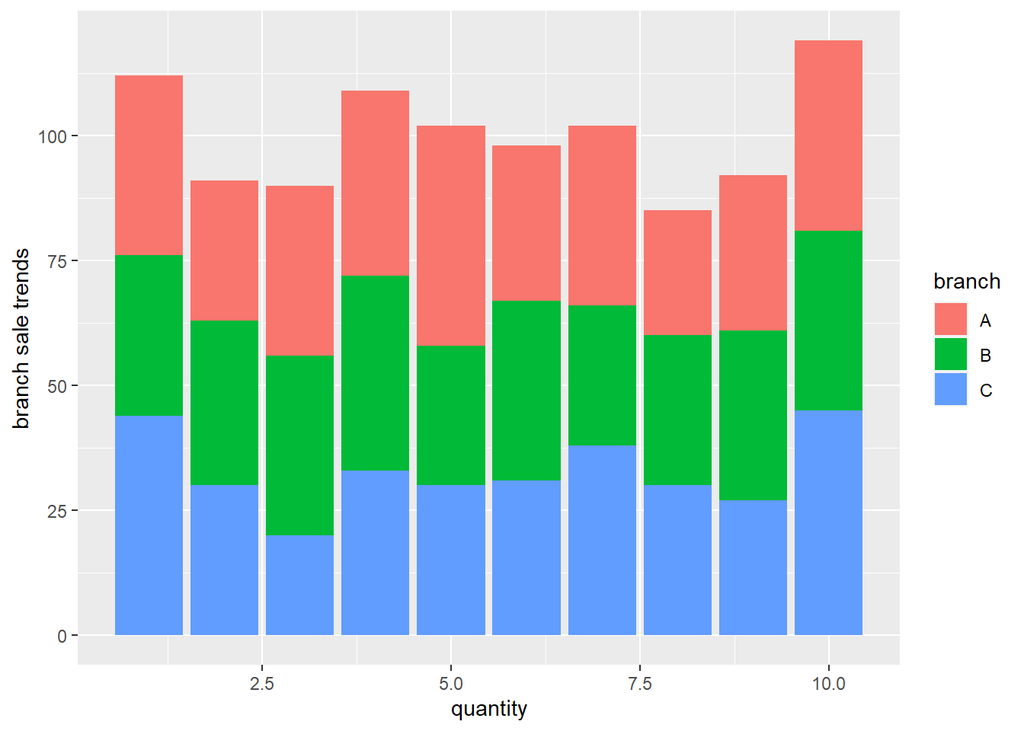

```r
sales1_date %>%
ggplot() +
aes(x = quantity, branxh = ..count../nrow(sales1_date), fill = branch) +
geom_bar() +
ylab("branch sale trends")
```

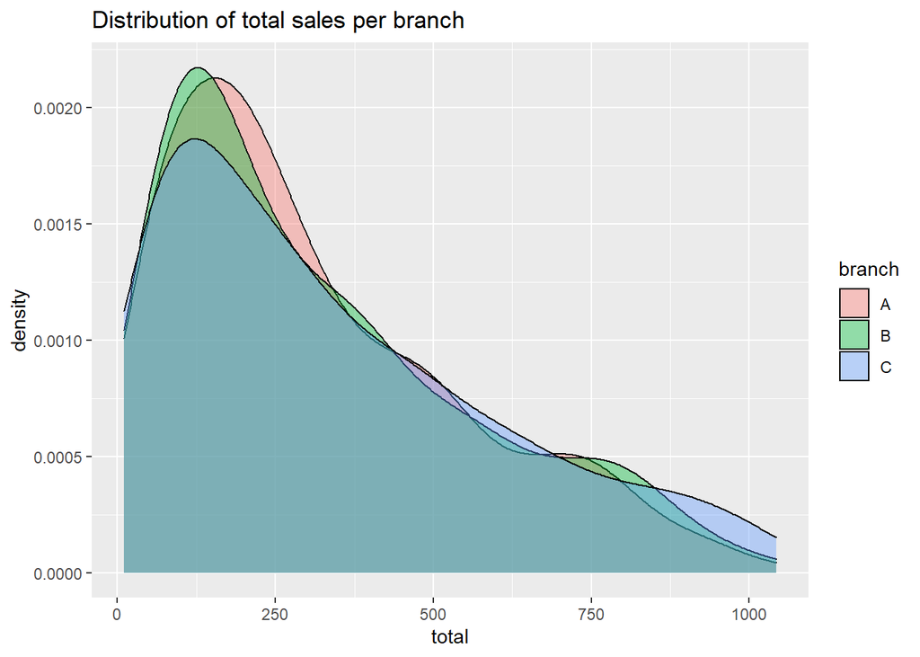

```r
#Distribution of income per Branch
ggplot(sales1_date,aes(x = total, fill = branch)) +geom_density(alpha = 0.4) +labs(title = "Distribution of total sales per branch")
```

branch A and B have highest sales between 1 & 300, then all branches experience low sales toward 100 shilling.

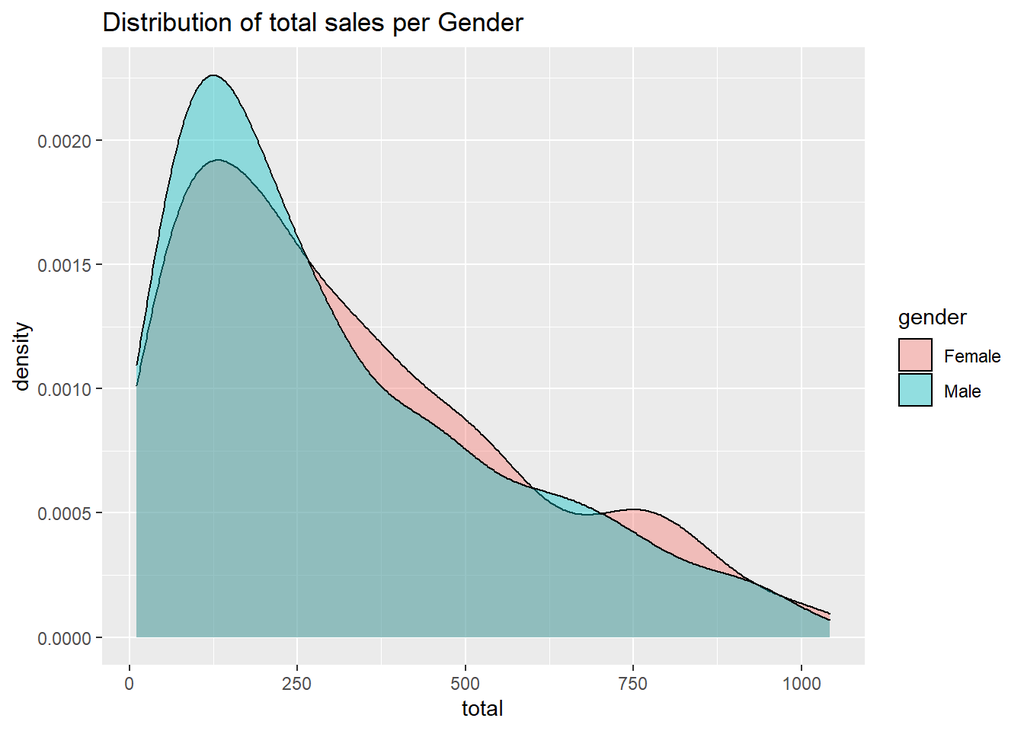

```r
#Distribution of income per Gender
ggplot(sales1_date,aes(x = total, fill = gender)) +geom_density(alpha = 0.4) +labs(title = "Distribution of total sales per Gender")
```

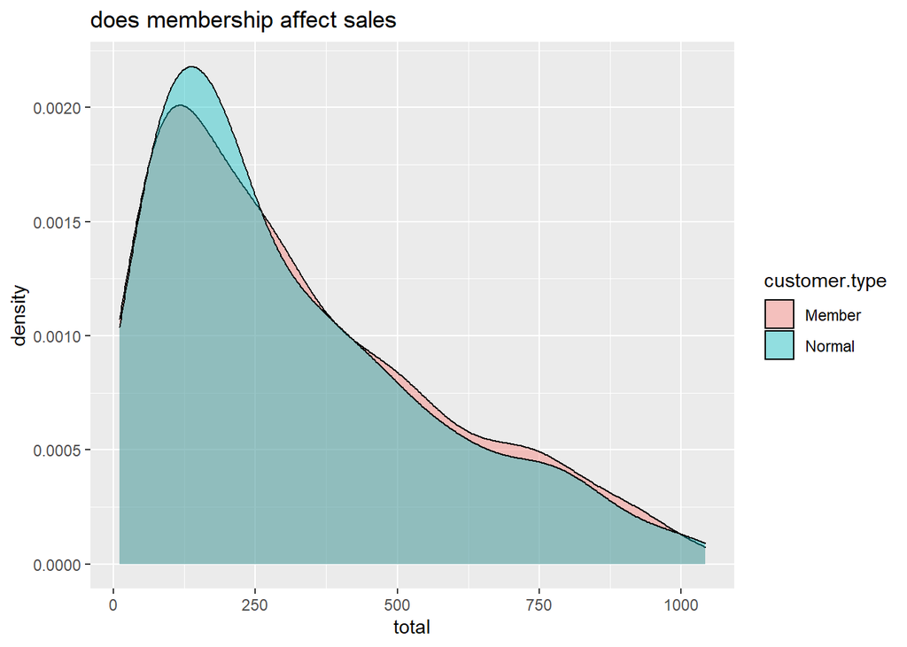

```r
#Distribution of income per Gender
ggplot(sales1_date,aes(x = total, fill = customer.type)) +geom_density(alpha = 0.4) +labs(title = "does membership affect sales")
```

```r
library(ggplot2)
library(corrplot)
#Printing out correlations in our dataset
cols <-cor(sales1_num)
cols
```

```
##                           unit.price    quantity       cogs
## unit.price               1.000000000  0.01077756  0.6339621
## quantity                 0.010777564  1.00000000  0.7055102
## cogs                     0.633962089  0.70551019  1.0000000
## gross.margin.percentage           NA          NA         NA
## gross.income             0.633962089  0.70551019  1.0000000
## rating                  -0.008777507 -0.01581490 -0.0364417
## total                    0.633962089  0.70551019  1.0000000
##                         gross.margin.percentage gross.income       rating
## unit.price                                   NA    0.6339621 -0.008777507
## quantity                                     NA    0.7055102 -0.015814905
## cogs                                         NA    1.0000000 -0.036441705
## gross.margin.percentage                       1           NA           NA
## gross.income                                 NA    1.0000000 -0.036441705
## rating                                       NA   -0.0364417  1.000000000
## total                                        NA    1.0000000 -0.036441705
##                              total
## unit.price               0.6339621
## quantity                 0.7055102
## cogs                     1.0000000
## gross.margin.percentage         NA
## gross.income             1.0000000
## rating                  -0.0364417
## total                    1.0000000
```

```r
#removing the grossmargin percantage as it has std of 0.
sales1_numt[ ,c('gross.margin.percentage')] <- list(NULL)
```

```r
#Printing out correlations in our dataset
cols <-cor(sales1_numt)
cols
```

```
##                unit.price    quantity       cogs gross.income       rating
## unit.price    1.000000000  0.01077756  0.6339621    0.6339621 -0.008777507
## quantity      0.010777564  1.00000000  0.7055102    0.7055102 -0.015814905
## cogs          0.633962089  0.70551019  1.0000000    1.0000000 -0.036441705
## gross.income  0.633962089  0.70551019  1.0000000    1.0000000 -0.036441705
## rating       -0.008777507 -0.01581490 -0.0364417   -0.0364417  1.000000000
## total         0.633962089  0.70551019  1.0000000    1.0000000 -0.036441705
##                   total
## unit.price    0.6339621
## quantity      0.7055102
## cogs          1.0000000
## gross.income  1.0000000
## rating       -0.0364417
## total         1.0000000
```

[figure not shown]

```r
corrplot(cor(cols), method="shade", tl.col="black", tl.srt=45)
```

There is an evident of positive correlation between the following columns:

cogs gross income total unit price

# 6. Implement the Solution

## Part 1: Dimensionality Reduction

### PCA

```r
#We had already ran the numericals and dropped redundant columns
#we named it sales1_numt

pca <- prcomp(sales1_numt[,c(1:6)], center = TRUE, scale = TRUE)
summary(pca)
```

```
## Importance of components:
##                           PC1    PC2    PC3    PC4      PC5       PC6
## Standard deviation     1.9817 1.0002 0.9939 0.2909 2.89e-16 1.377e-16
## Proportion of Variance 0.6545 0.1667 0.1646 0.0141 0.00e+00 0.000e+00
## Cumulative Proportion  0.6545 0.8213 0.9859 1.0000 1.00e+00 1.000e+00
```

Proportion of Variance: This is the amount of variance the component accounts for in the data, ie PC1 accounts for 65.5% of total variance in the data alone! Cumulative Proportion: This is simply the accumulated amount of explained variance, ie. if we used the first 3 components we would be able to account for 98% of total variance in the data

```r
#used the string function to know which variables were to be consindered
str(pca)
```

```
## List of 5
##  $ sdev    : num [1:6] 1.98 1.00 9.94e-01 2.91e-01 2.89e-16 ...
##  $ rotation: num [1:6, 1:6] -0.3281 -0.3649 -0.5029 -0.5029 0.0217 ...
##   ..- attr(*, "dimnames")=List of 2
##   .. ..$ : chr [1:6] "unit.price" "quantity" "cogs" "gross.income" ...
##   .. ..$ : chr [1:6] "PC1" "PC2" "PC3" "PC4" ...
##  $ center  : Named num [1:6] 55.67 5.51 307.59 15.38 6.97 ...
##   ..- attr(*, "names")= chr [1:6] "unit.price" "quantity" "cogs" "gross.income" ...
##  $ scale   : Named num [1:6] 26.49 2.92 234.18 11.71 1.72 ...
##   ..- attr(*, "names")= chr [1:6] "unit.price" "quantity" "cogs" "gross.income" ...
##  $ x       : num [1:1000, 1:6] -1.781 2.087 -0.173 -1.343 -2.497 ...
##   ..- attr(*, "dimnames")=List of 2
##   .. ..$ : NULL
##   .. ..$ : chr [1:6] "PC1" "PC2" "PC3" "PC4" ...
##  - attr(*, "class")= chr "prcomp"
```

### Here we note the center point ($center), scaling ($scale),standard deviation(sdev) of each principal component.

### The relationship (correlation or anticorrelation, etc) between the initial variables and the principal components ($rotation). ### The values of each sample in terms of the principal components ($x)

```r
# We will now plot our pca. This will provide us with some very useful insights

# Installing our ggbiplot visualisation package
#
library(devtools)
#install_github("vqv/ggbiplot")
```

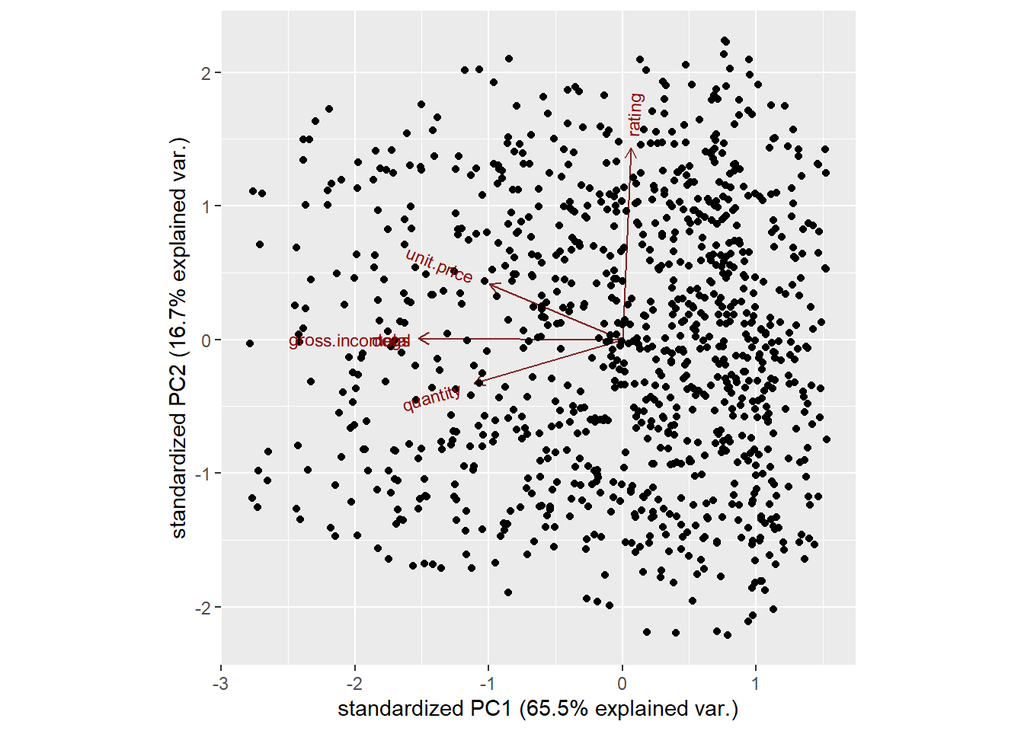

```r
# Then Loading our ggbiplot library
#
library(ggbiplot)
ggbiplot(pca)
```

we notice that unit price, quantity, rating and grossincome were the four variables to be highly consindered during modelling.

```r
#adding more details
#plotting the PCA to see the above visually
#we will use ggbiplot library
library(ggbiplot)
```

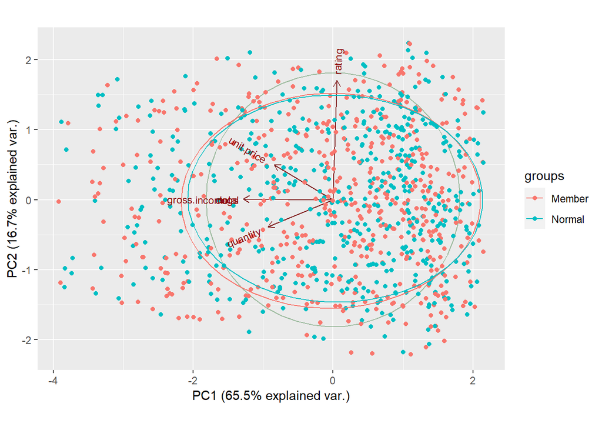

```r
ggbiplot(pca, obs.scale = 0.5, var.scale = 0.5, groups = sales1_date$customer.type,ellipse = TRUE, circle = TRUE)
```

## Part 2: Feature Selection

### Wrapper Method

```r
# Installing and loading our clustvarsel package


library(clustvarsel)
# Installing and loading our mclust package
library(mclust)
```

```r
# Sequential forward greedy search (default)
# ---
#
out = clustvarsel(sales1_numt)
out
```

```
## ------------------------------------------------------
## Variable selection for Gaussian model-based clustering
## Stepwise (forward/backward) greedy search
## ------------------------------------------------------
##
##  Variable proposed Type of step   BICclust Model G   BICdiff Decision
##           quantity          Add  -4308.761     E 9  687.4466 Accepted
##               cogs          Add -16306.851   VEV 9 1083.0132 Accepted
##         unit.price          Add -21393.079   EVV 7 2812.3733 Accepted
##         unit.price       Remove -16306.851   VEV 9 2812.3733 Rejected
##             rating          Add -25510.859   EVV 7 -184.0917 Rejected
##         unit.price       Remove -16306.851   VEV 9 2812.3733 Rejected
##
## Selected subset: quantity, cogs, unit.price
```

we see that the columns quantity,cogs and unitprice have been accepted and can be used for modelling.This is a more accurate way of feature selection.

```r
# The selection algorithm would indicate that the subset
# we use for the clustering model is composed of variables quantity, unit price, cogs
# and that other variables should be rejected.
# Having identified the variables that we use, we proceed to build the clustering model:
# ---
#

Subset1 = sales1_numt[,out$subset]
mod = Mclust(Subset1)
summary(mod)
```

```
## ----------------------------------------------------
## Gaussian finite mixture model fitted by EM algorithm
## ----------------------------------------------------
##
## Mclust EVV (ellipsoidal, equal volume) model with 7 components:
##
##  log-likelihood    n df       BIC       ICL
##       -10478.95 1000 63 -21393.08 -21446.89
##
## Clustering table:
##   1   2   3   4   5   6   7
## 173 134 126 148 128 142 149
```

# 7. Recommendation

From Dimentionality reduction model: 1.Quantity 2.Unit price 3.gross income 4.rating

feater selection model: 1.Quantity 2.Cogs 3.Unit price

The feature selection model gave us the best outcome for consideration of what impact the sales in carefore kenya.